# Part II - (PISA Data 2012)

## by (Charles Baba Odogun)

PISA is a survey of students' skills and knowledge as they approach the end of compulsory education. It is not a conventional school test. Rather than examining how well students have learned the school curriculum, it looks at how well prepared they are for life beyond school.

Around 510,000 students( 15-year-olds) in 65 economies took part in the PISA 2012 assessment of reading, mathematics and science. . Of those economies, 44 took part in an assessment of creative problem solving and 18 in an assessment of financial literacy.

# Investigation Overview

## Mean Distribution of Scores

I want to identify the kind of distribution in each score variable. We see that all score variables follow a normal mean distribution,with scores ranging from 200 - 800 points and from all 3 scores we can see that majority of the students have the mean score of 500 points

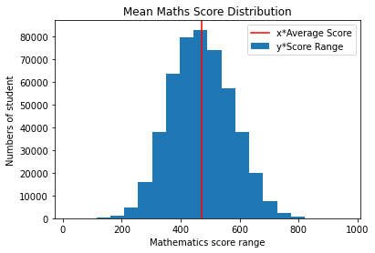

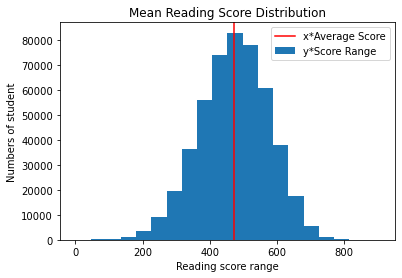

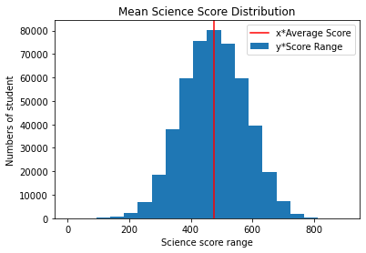

## Difference in performance in regards to gender

I want to identify the kind of distribution in each score variable in regards to the student genders. When we examine the bar charts below, you will notice that,in maths boys did more than girls, in reading girls were better readers and in the science, there isnt much difference in their perfomance.

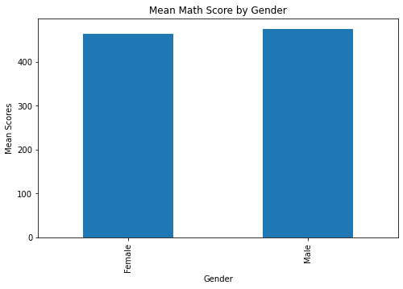

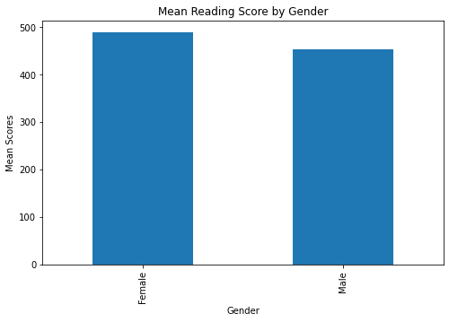

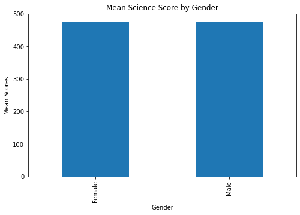

## Countries distribution

I want to identify the kind of distribution of the economies that are represented in our data set. From the chart below. we discover that Mexico has the highest number of students with 33806, followed by Italy with 31073,Spain with 25313 and Canada 21544 students.

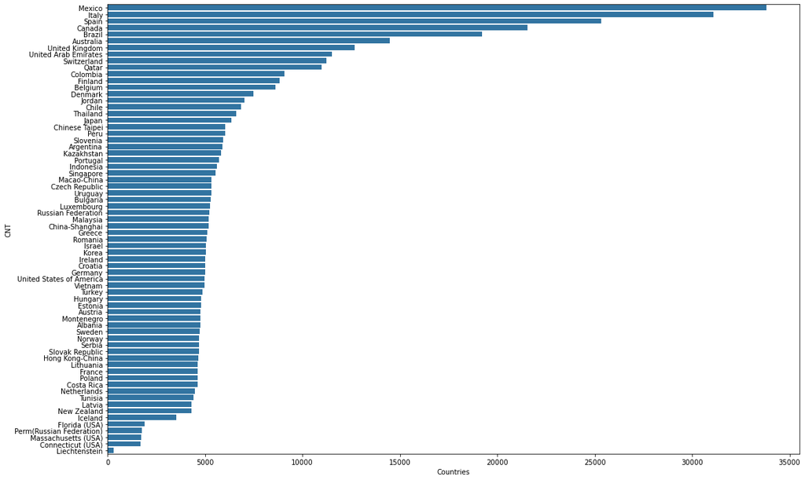

# Family structure distribution

I want to identify the kind of family structures distribution of the students from economies that are represented in our data set. And from what we can see , there are lots of students from a two family structure.

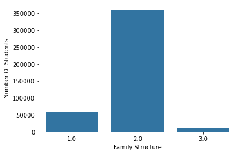

## OECD Countries distribution

I want to check the performance of students from both OECD and Non- OECD countires in all three duscipline. And from the pie chart below, student from OECD countires performed better in all discipline.

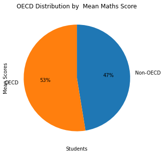

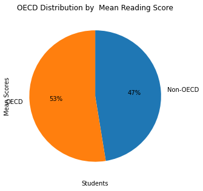

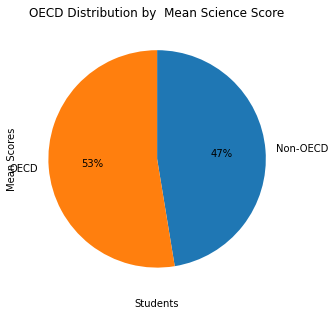